# INN Hotels Project

## Context

A significant number of hotel bookings are called-off due to cancellations or no-shows. The typical reasons for cancellations include change of plans, scheduling conflicts, etc. This is often made easier by the option to do so free of charge or preferably at a low cost which is beneficial to hotel guests but it is a less desirable and possibly revenue-diminishing factor for hotels to deal with. Such losses are particularly high on last-minute cancellations.

The new technologies involving online booking channels have dramatically changed customers’ booking possibilities and behavior. This adds a further dimension to the challenge of how hotels handle cancellations, which are no longer limited to traditional booking and guest characteristics.

The cancellation of bookings impact a hotel on various fronts:

- Loss of resources (revenue) when the hotel cannot resell the room.
- Additional costs of distribution channels by increasing commissions or paying for publicity to help sell these rooms.
- Lowering prices last minute, so the hotel can resell a room, resulting in reducing the profit margin.
- Human resources to make arrangements for the guests.

## Objective

The increasing number of cancellations calls for a Machine Learning based solution that can help in predicting which booking is likely to be canceled. INN Hotels Group has a chain of hotels in Portugal, they are facing problems with the high number of booking cancellations and have reached out to your firm for data-driven solutions. You as a data scientist have to analyze the data provided to find which factors have a high influence on booking cancellations, build a predictive model that can predict which booking is going to be canceled in advance, and help in formulating profitable policies for cancellations and refunds.

## Data Description

The data contains the different attributes of customers' booking details. The detailed data dictionary is given below.

**Data Dictionary**

- Booking_ID: unique identifier of each booking
- no_of_adults: Number of adults
- no_of_children: Number of Children
- no_of_weekend_nights: Number of weekend nights (Saturday or Sunday) the guest stayed or booked to stay at the hotel
- no_of_week_nights: Number of week nights (Monday to Friday) the guest stayed or booked to stay at the hotel
- type_of_meal_plan: Type of meal plan booked by the customer:
  - Not Selected – No meal plan selected
  - Meal Plan 1 – Breakfast
  - Meal Plan 2 – Half board (breakfast and one other meal)
  - Meal Plan 3 – Full board (breakfast, lunch, and dinner)
- required_car_parking_space: Does the customer require a car parking space? (0 - No, 1- Yes)
- room_type_reserved: Type of room reserved by the customer. The values are ciphered (encoded) by INN Hotels.
- lead_time: Number of days between the date of booking and the arrival date
- arrival_year: Year of arrival date
- arrival_month: Month of arrival date
- arrival_date: Date of the month
- market_segment_type: Market segment designation.
- repeated_guest: Is the customer a repeated guest? (0 - No, 1- Yes)
- no_of_previous_cancellations: Number of previous bookings that were canceled by the customer prior to the current booking
- no_of_previous_bookings_not_canceled: Number of previous bookings not canceled by the customer prior to the current booking
- avg_price_per_room: Average price per day of the reservation; prices of the rooms are dynamic. (in euros)
- no_of_special_requests: Total number of special requests made by the customer (e.g. high floor, view from the room, etc)
- booking_status: Flag indicating if the booking was canceled or not.

## Importing necessary libraries and data

```python
# Code to help make the Python code more structured automatically
%load_ext nb_black

# Library to suppress warnings or deprecation notes
import warnings

warnings.filterwarnings("ignore")

# Libraries to help with reading and manipulating data

import pandas as pd
import numpy as np

# Library to split data
from sklearn.model_selection import train_test_split

# libaries to help with data visualization
import matplotlib.pyplot as plt
import seaborn as sns

# Removes the limit for the number of displayed columns
pd.set_option("display.max_columns", None)
# Sets the limit for the number of displayed rows
pd.set_option("display.max_rows", 200)

# Libraries to build decision tree classifier
from sklearn.tree import DecisionTreeClassifier
from sklearn import tree

# To tune different models
from sklearn.model_selection import GridSearchCV

# To perform statistical analysis
import scipy.stats as stats

# To get diferent metric scores
from sklearn.metrics import (
    f1_score,
    accuracy_score,
    recall_score,
    precision_score,
    confusion_matrix,
    plot_confusion_matrix,
    make_scorer,
)

# To build model for prediction
import statsmodels.stats.api as sms
from statsmodels.stats.outliers_influence import variance_inflation_factor
import statsmodels.api as sm
from statsmodels.tools.tools import add_constant
from sklearn.linear_model import LogisticRegression

# this will help in making the Python code more structured automatically (good coding practice)
%load_ext nb_black

# import warnings

# warnings.filterwarnings("ignore")

# Libraries to help with reading and manipulating data

import pandas as pd
import numpy as np

# Library to split data
from sklearn.model_selection import train_test_split

# libaries to help with data visualization
import matplotlib.pyplot as plt
import seaborn as sns

# Removes the limit for the number of displayed columns
pd.set_option("display.max_columns", None)
# Sets the limit for the number of displayed rows
pd.set_option("display.max_rows", 200)


# To build model for prediction
import statsmodels.stats.api as sms
from statsmodels.stats.outliers_influence import variance_inflation_factor
import statsmodels.api as sm
from statsmodels.tools.tools import add_constant
from sklearn.linear_model import LogisticRegression
from sklearn import metrics

# To get different metric scores
from sklearn.metrics import (
    f1_score,
    accuracy_score,
    recall_score,
    precision_score,
    confusion_matrix,
    roc_auc_score,
    plot_confusion_matrix,
    precision_recall_curve,
    roc_curve,
)
```

```
The nb_black extension is already loaded. To reload it, use:
  %reload_ext nb_black
```

```python
df = pd.read_csv("INNHotelsGroup.csv")
```

```python
df1 = df.copy()
```

## Data Overview

- Observations
- Sanity checks

```python
# To view the first few rows of the dataset
df1.head()
```

|  | Booking_ID | no_of_adults | no_of_children | no_of_weekend_nights | no_of_week_nights | type_of_meal_plan | required_car_parking_space | room_type_reserved | lead_time | arrival_year | arrival_month | arrival_date | market_segment_type | repeated_guest | no_of_previous_cancellations | no_of_previous_bookings_not_canceled | avg_price_per_room | no_of_special_requests | booking_status |
| --- | --- | --- | --- | --- | --- | --- | --- | --- | --- | --- | --- | --- | --- | --- | --- | --- | --- | --- | --- |
| 0 | INN00001 | 2 | 0 | 1 | 2 | Meal Plan 1 | 0 | Room_Type 1 | 224 | 2017 | 10 | 2 | Offline | 0 | 0 | 0 | 65.00 | 0 | Not_Canceled |
| 1 | INN00002 | 2 | 0 | 2 | 3 | Not Selected | 0 | Room_Type 1 | 5 | 2018 | 11 | 6 | Online | 0 | 0 | 0 | 106.68 | 1 | Not_Canceled |
| 2 | INN00003 | 1 | 0 | 2 | 1 | Meal Plan 1 | 0 | Room_Type 1 | 1 | 2018 | 2 | 28 | Online | 0 | 0 | 0 | 60.00 | 0 | Canceled |
| 3 | INN00004 | 2 | 0 | 0 | 2 | Meal Plan 1 | 0 | Room_Type 1 | 211 | 2018 | 5 | 20 | Online | 0 | 0 | 0 | 100.00 | 0 | Canceled |
| 4 | INN00005 | 2 | 0 | 1 | 1 | Not Selected | 0 | Room_Type 1 | 48 | 2018 | 4 | 11 | Online | 0 | 0 | 0 | 94.50 | 0 | Canceled |

```python
# To check or sample 10 random rows, the following code is used
np.random.seed(1)
df1.sample(n=10)
```

|  | Booking_ID | no_of_adults | no_of_children | no_of_weekend_nights | no_of_week_nights | type_of_meal_plan | required_car_parking_space | room_type_reserved | lead_time | arrival_year | arrival_month | arrival_date | market_segment_type | repeated_guest | no_of_previous_cancellations | no_of_previous_bookings_not_canceled | avg_price_per_room | no_of_special_requests | booking_status |
| --- | --- | --- | --- | --- | --- | --- | --- | --- | --- | --- | --- | --- | --- | --- | --- | --- | --- | --- | --- |
| 30392 | INN30393 | 1 | 0 | 1 | 0 | Not Selected | 0 | Room_Type 1 | 53 | 2018 | 9 | 11 | Online | 0 | 0 | 0 | 94.32 | 0 | Not_Canceled |
| 6685 | INN06686 | 2 | 0 | 1 | 2 | Meal Plan 1 | 0 | Room_Type 1 | 63 | 2018 | 4 | 22 | Online | 0 | 0 | 0 | 105.30 | 1 | Canceled |
| 8369 | INN08370 | 2 | 0 | 2 | 3 | Meal Plan 1 | 0 | Room_Type 4 | 55 | 2018 | 9 | 11 | Online | 0 | 0 | 0 | 106.24 | 0 | Not_Canceled |
| 2055 | INN02056 | 2 | 0 | 0 | 2 | Not Selected | 0 | Room_Type 1 | 53 | 2017 | 12 | 29 | Online | 0 | 0 | 0 | 81.00 | 1 | Not_Canceled |
| 10969 | INN10970 | 1 | 0 | 2 | 4 | Meal Plan 1 | 0 | Room_Type 1 | 245 | 2018 | 7 | 6 | Offline | 0 | 0 | 0 | 110.00 | 0 | Canceled |
| 24881 | INN24882 | 2 | 0 | 3 | 7 | Meal Plan 1 | 0 | Room_Type 2 | 231 | 2018 | 8 | 1 | Online | 0 | 0 | 0 | 81.82 | 2 | Canceled |
| 28658 | INN28659 | 2 | 0 | 0 | 3 | Meal Plan 2 | 0 | Room_Type 1 | 71 | 2018 | 5 | 10 | Offline | 0 | 0 | 0 | 126.00 | 1 | Not_Canceled |
| 20853 | INN20854 | 2 | 0 | 1 | 2 | Meal Plan 1 | 0 | Room_Type 1 | 66 | 2017 | 10 | 9 | Offline | 0 | 0 | 0 | 75.00 | 0 | Canceled |
| 8501 | INN08502 | 2 | 0 | 0 | 3 | Meal Plan 1 | 0 | Room_Type 2 | 40 | 2018 | 1 | 14 | Online | 0 | 0 | 0 | 77.55 | 1 | Not_Canceled |
| 1942 | INN01943 | 2 | 0 | 0 | 2 | Meal Plan 1 | 0 | Room_Type 1 | 63 | 2018 | 8 | 9 | Online | 0 | 0 | 0 | 144.90 | 2 | Not_Canceled |

#### Observation:

Ten random rows of the dataset have been displayed and this gives an idea of how the columns have been filled.

# To check the number of rows and columns in the dataset

df1.shape

#### Observaton:

There are 36275 rows and 19 columns in this dataset

```python
df1.info()
```

```
<class 'pandas.core.frame.DataFrame'>
RangeIndex: 36275 entries, 0 to 36274
Data columns (total 19 columns):
 #   Column                                Non-Null Count  Dtype
---  ------                                --------------  -----
 0   Booking_ID                            36275 non-null  object
 1   no_of_adults                          36275 non-null  int64
 2   no_of_children                        36275 non-null  int64
 3   no_of_weekend_nights                  36275 non-null  int64
 4   no_of_week_nights                     36275 non-null  int64
 5   type_of_meal_plan                     36275 non-null  object
 6   required_car_parking_space            36275 non-null  int64
 7   room_type_reserved                    36275 non-null  object
 8   lead_time                             36275 non-null  int64
 9   arrival_year                          36275 non-null  int64
 10  arrival_month                         36275 non-null  int64
 11  arrival_date                          36275 non-null  int64
 12  market_segment_type                   36275 non-null  object
 13  repeated_guest                        36275 non-null  int64
 14  no_of_previous_cancellations          36275 non-null  int64
 15  no_of_previous_bookings_not_canceled  36275 non-null  int64
 16  avg_price_per_room                    36275 non-null  float64
 17  no_of_special_requests                36275 non-null  int64
 18  booking_status                        36275 non-null  object
dtypes: float64(1), int64(13), object(5)
memory usage: 5.3+ MB
```

#### Observations:

```python
# Changing object data types to categorical using for loops
for feature in df1.columns:
    if df1[feature].dtype == "object":
        df1[feature] = pd.Categorical(df1[feature])
df1.info()
```

```
<class 'pandas.core.frame.DataFrame'>
RangeIndex: 36275 entries, 0 to 36274
Data columns (total 19 columns):
 #   Column                                Non-Null Count  Dtype
---  ------                                --------------  -----
 0   Booking_ID                            36275 non-null  category
 1   no_of_adults                          36275 non-null  int64
 2   no_of_children                        36275 non-null  int64
 3   no_of_weekend_nights                  36275 non-null  int64
 4   no_of_week_nights                     36275 non-null  int64
 5   type_of_meal_plan                     36275 non-null  category
 6   required_car_parking_space            36275 non-null  int64
 7   room_type_reserved                    36275 non-null  category
 8   lead_time                             36275 non-null  int64
 9   arrival_year                          36275 non-null  int64
 10  arrival_month                         36275 non-null  int64
 11  arrival_date                          36275 non-null  int64
 12  market_segment_type                   36275 non-null  category
 13  repeated_guest                        36275 non-null  int64
 14  no_of_previous_cancellations          36275 non-null  int64
 15  no_of_previous_bookings_not_canceled  36275 non-null  int64
 16  avg_price_per_room                    36275 non-null  float64
 17  no_of_special_requests                36275 non-null  int64
 18  booking_status                        36275 non-null  category
dtypes: category(5), float64(1), int64(13)
memory usage: 5.4 MB
```

#### Observation:

All object data types have been changed to categorical data types

```python
# Changing 'arrival_year', 'arrival_month', 'arrival_date', 'required_car_parking_space' and 'repeated_guest' to categorical data types
df1["arrival_date"] = df1.arrival_date.astype("category")
df1["arrival_month"] = df1.arrival_month.astype("category")
df1["arrival_year"] = df1.arrival_year.astype("category")
df1["repeated_guest"] = df1.repeated_guest.astype("category")
df1["required_car_parking_space"] = df1.required_car_parking_space.astype("category")

df1.info()  # Use info() to print a concise summary of the DataFrame
```

```
<class 'pandas.core.frame.DataFrame'>
RangeIndex: 36275 entries, 0 to 36274
Data columns (total 19 columns):
 #   Column                                Non-Null Count  Dtype
---  ------                                --------------  -----
 0   Booking_ID                            36275 non-null  category
 1   no_of_adults                          36275 non-null  int64
 2   no_of_children                        36275 non-null  int64
 3   no_of_weekend_nights                  36275 non-null  int64
 4   no_of_week_nights                     36275 non-null  int64
 5   type_of_meal_plan                     36275 non-null  category
 6   required_car_parking_space            36275 non-null  category
 7   room_type_reserved                    36275 non-null  category
 8   lead_time                             36275 non-null  int64
 9   arrival_year                          36275 non-null  category
 10  arrival_month                         36275 non-null  category
 11  arrival_date                          36275 non-null  category
 12  market_segment_type                   36275 non-null  category
 13  repeated_guest                        36275 non-null  category
 14  no_of_previous_cancellations          36275 non-null  int64
 15  no_of_previous_bookings_not_canceled  36275 non-null  int64
 16  avg_price_per_room                    36275 non-null  float64
 17  no_of_special_requests                36275 non-null  int64
 18  booking_status                        36275 non-null  category
dtypes: category(10), float64(1), int64(8)
memory usage: 4.2 MB
```

```python
# code for number of unique entries per column
df1.nunique()
```

```
Booking_ID                              36275
no_of_adults                                5
no_of_children                              6
no_of_weekend_nights                        8
no_of_week_nights                          18
type_of_meal_plan                           4
required_car_parking_space                  2
room_type_reserved                          7
lead_time                                 352
arrival_year                                2
arrival_month                              12
arrival_date                               31
market_segment_type                         5
repeated_guest                              2
no_of_previous_cancellations                9
no_of_previous_bookings_not_canceled       59
avg_price_per_room                       3930
no_of_special_requests                      6
booking_status                              2
dtype: int64
```

#### Observations:

```python
# To check if there is any missing data, the following code is used
df1.isnull().sum().sort_values(ascending=False)
```

```
Booking_ID                              0
arrival_month                           0
no_of_special_requests                  0
avg_price_per_room                      0
no_of_previous_bookings_not_canceled    0
no_of_previous_cancellations            0
repeated_guest                          0
market_segment_type                     0
arrival_date                            0
arrival_year                            0
no_of_adults                            0
lead_time                               0
room_type_reserved                      0
required_car_parking_space              0
type_of_meal_plan                       0
no_of_week_nights                       0
no_of_weekend_nights                    0
no_of_children                          0
booking_status                          0
dtype: int64
```

#### Observation

1. There is no missing data found in this data set.
2. Although there are 'Not selected' entries under 'type_of_meal_plan', it will not be considered as missing data and will be treated during data preparation.

```python
df1.duplicated().sum()
```

```
0
```

#### Observation:

There are no duplicated entries in the dataset

```python
# Code for a statistical summary of the dataset
df1.describe(include="all").T
```

|  | count | unique | top | freq | mean | std | min | 25% | 50% | 75% | max |
| --- | --- | --- | --- | --- | --- | --- | --- | --- | --- | --- | --- |
| Booking_ID | 36275 | 36275 | INN00001 | 1 | NaN | NaN | NaN | NaN | NaN | NaN | NaN |
| no_of_adults | 36275.0 | NaN | NaN | NaN | 1.844962 | 0.518715 | 0.0 | 2.0 | 2.0 | 2.0 | 4.0 |
| no_of_children | 36275.0 | NaN | NaN | NaN | 0.105279 | 0.402648 | 0.0 | 0.0 | 0.0 | 0.0 | 10.0 |
| no_of_weekend_nights | 36275.0 | NaN | NaN | NaN | 0.810724 | 0.870644 | 0.0 | 0.0 | 1.0 | 2.0 | 7.0 |
| no_of_week_nights | 36275.0 | NaN | NaN | NaN | 2.2043 | 1.410905 | 0.0 | 1.0 | 2.0 | 3.0 | 17.0 |
| type_of_meal_plan | 36275 | 4 | Meal Plan 1 | 27835 | NaN | NaN | NaN | NaN | NaN | NaN | NaN |
| required_car_parking_space | 36275.0 | 2.0 | 0.0 | 35151.0 | NaN | NaN | NaN | NaN | NaN | NaN | NaN |
| room_type_reserved | 36275 | 7 | Room_Type 1 | 28130 | NaN | NaN | NaN | NaN | NaN | NaN | NaN |
| lead_time | 36275.0 | NaN | NaN | NaN | 85.232557 | 85.930817 | 0.0 | 17.0 | 57.0 | 126.0 | 443.0 |
| arrival_year | 36275.0 | 2.0 | 2018.0 | 29761.0 | NaN | NaN | NaN | NaN | NaN | NaN | NaN |
| arrival_month | 36275.0 | 12.0 | 10.0 | 5317.0 | NaN | NaN | NaN | NaN | NaN | NaN | NaN |
| arrival_date | 36275.0 | 31.0 | 13.0 | 1358.0 | NaN | NaN | NaN | NaN | NaN | NaN | NaN |
| market_segment_type | 36275 | 5 | Online | 23214 | NaN | NaN | NaN | NaN | NaN | NaN | NaN |
| repeated_guest | 36275.0 | 2.0 | 0.0 | 35345.0 | NaN | NaN | NaN | NaN | NaN | NaN | NaN |
| no_of_previous_cancellations | 36275.0 | NaN | NaN | NaN | 0.023349 | 0.368331 | 0.0 | 0.0 | 0.0 | 0.0 | 13.0 |
| no_of_previous_bookings_not_canceled | 36275.0 | NaN | NaN | NaN | 0.153411 | 1.754171 | 0.0 | 0.0 | 0.0 | 0.0 | 58.0 |
| avg_price_per_room | 36275.0 | NaN | NaN | NaN | 103.423539 | 35.089424 | 0.0 | 80.3 | 99.45 | 120.0 | 540.0 |
| no_of_special_requests | 36275.0 | NaN | NaN | NaN | 0.619655 | 0.786236 | 0.0 | 0.0 | 0.0 | 1.0 | 5.0 |
| booking_status | 36275 | 2 | Not_Canceled | 24390 | NaN | NaN | NaN | NaN | NaN | NaN | NaN |

## Exploratory Data Analysis (EDA)

- EDA is an important part of any project involving data.
- It is important to investigate and understand the data better before building a model with it.
- A few questions have been mentioned below which will help you approach the analysis in the right manner and generate insights from the data.
- A thorough analysis of the data, in addition to the questions mentioned below, should be done.

**Leading Questions**:

1. What are the busiest months in the hotel?
2. Which market segment do most of the guests come from?
3. Hotel rates are dynamic and change according to demand and customer demographics. What are the differences in room prices in different market segments?
4. What percentage of bookings are canceled?
5. Repeating guests are the guests who stay in the hotel often and are important to brand equity. What percentage of repeating guests cancel?
6. Many guests have special requirements when booking a hotel room. Do these requirements affect booking cancellation?

### Leading Questions

```python
# function to plot a boxplot and a histogram along the same scale.


def histogram_boxplot(data, feature, figsize=(12, 7), kde=False, bins=None):
    """
    Boxplot and histogram combined

    data: dataframe
    feature: dataframe column
    figsize: size of figure (default (12,7))
    kde: whether to show the density curve (default False)
    bins: number of bins for histogram (default None)
    """
    f2, (ax_box2, ax_hist2) = plt.subplots(
        nrows=2,  # Number of rows of the subplot grid= 2
        sharex=True,  # x-axis will be shared among all subplots
        gridspec_kw={"height_ratios": (0.25, 0.75)},
        figsize=figsize,
    )  # creating the 2 subplots
    sns.boxplot(
        data=data, x=feature, ax=ax_box2, showmeans=True, color="violet"
    )  # boxplot will be created and a star will indicate the mean value of the column
    sns.histplot(
        data=data, x=feature, kde=kde, ax=ax_hist2, bins=bins, palette="winter"
    ) if bins else sns.histplot(
        data=data, x=feature, kde=kde, ax=ax_hist2
    )  # For histogram
    ax_hist2.axvline(
        data[feature].mean(), color="green", linestyle="--"
    )  # Add mean to the histogram
    ax_hist2.axvline(
        data[feature].median(), color="black", linestyle="-"
    )  # Add median to the histogram
```

```python
# function to create labeled barplots


def labeled_barplot(data, feature, perc=False, n=None):
    """
    Barplot with percentage at the top

    data: dataframe
    feature: dataframe column
    perc: whether to display percentages instead of count (default is False)
    n: displays the top n category levels (default is None, i.e., display all levels)
    """

    total = len(data[feature])  # length of the column
    count = data[feature].nunique()
    if n is None:
        plt.figure(figsize=(count + 1, 5))
    else:
        plt.figure(figsize=(n + 1, 5))

    plt.xticks(rotation=45, fontsize=15)
    ax = sns.countplot(
        data=data,
        x=feature,
        palette="Paired",
        order=data[feature].value_counts().index[:n].sort_values(),
    )

    for p in ax.patches:
        if perc == True:
            label = "{:.1f}%".format(
                100 * p.get_height() / total
            )  # percentage of each class of the category
        else:
            label = p.get_height()  # count of each level of the category

        x = p.get_x() + p.get_width() / 2  # width of the plot
        y = p.get_height()  # height of the plot

        ax.annotate(
            label,
            (x, y),
            ha="center",
            va="center",
            size=12,
            xytext=(0, 5),
            textcoords="offset points",
        )  # annotate the percentage

    plt.show()  # show the plot
```

### 1) Busiest Months

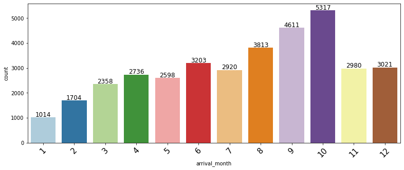

```python
labeled_barplot(df1, "arrival_month")
```

#### Observations:

1. Most bookings are made in October followed by September and August
2. The month with the least number of bo0kings is January.

### 2. Client Market Segments

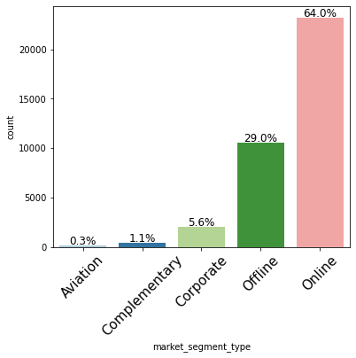

```python
labeled_barplot(df1, "market_segment_type", perc=True)
```

#### Observation:

Most guests are from the online market segment.

### 3. Market segment vs Room price

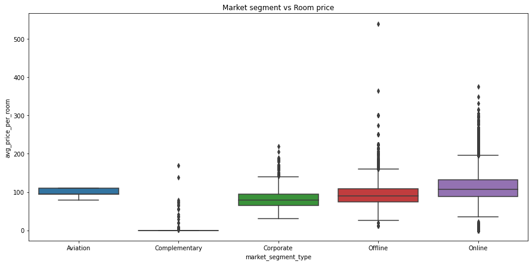

```python
plt.figure(figsize=(15, 7))
sns.boxplot(data=df1, x="market_segment_type", y="avg_price_per_room")
plt.title("Market segment vs Room price")
plt.show()
```

#### Observations:

1. Those who tend to get the smallest-priced rooms are complimenary.
2. Online bookings get rooms of a wide price range. Average price is about 100 euros.
3. Aviation bookings get rooms jut around the 100 euro range.
4. The remaining market segments ('corporate' and 'offline') get average room prices of less than 100 euros.

### 4. Percentage of Canceled Bookings

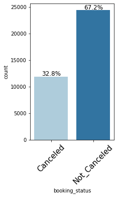

```
The percentage of canceled bookings is 32.76361130254997 %
```

```python
labeled_barplot(df1, "booking_status", perc=True)
print(
    "The percentage of canceled bookings is",
    ((df1["booking_status"] == "Canceled").sum() / len(df1["booking_status"]) * 100),
    "%",
)
```

#### Observation:

32.8% of bookings at the INN Hotels have been canceled.

### 5. Regular guests vs Cancelations

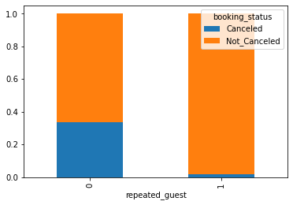

```python
pd.crosstab(df1["repeated_guest"], df["booking_status"], normalize="index").plot(
    kind="bar", stacked=True
)
plt.show()
```

#### Observation

Less than 5% of repeated guests cancel their bookings.

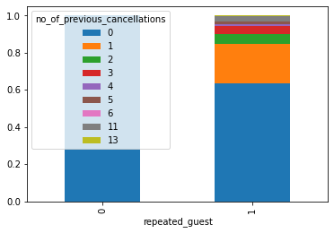

```python
pd.crosstab(
    df1["repeated_guest"], df["no_of_previous_cancellations"], normalize="index"
).plot(kind="bar", stacked=True)
plt.show()
```

#### Observation:

60% of repeated guests do not have a history of canceling bookings

### 6. Booking status vs Special requests

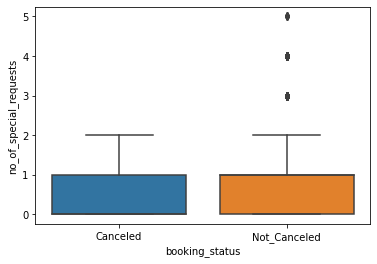

```python
sns.boxplot(data=df1, x="booking_status", y="no_of_special_requests")
plt.show()
```

#### Observation:

Clients who put in more special requests are less likely to cancel

### A) no_of_adults

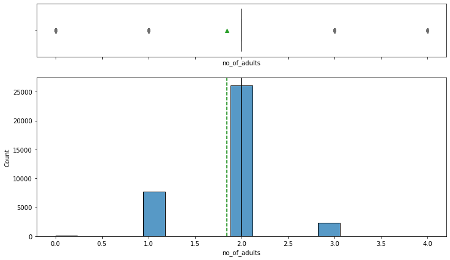

```python
histogram_boxplot(df1, "no_of_adults")
```

### B) no_of_children

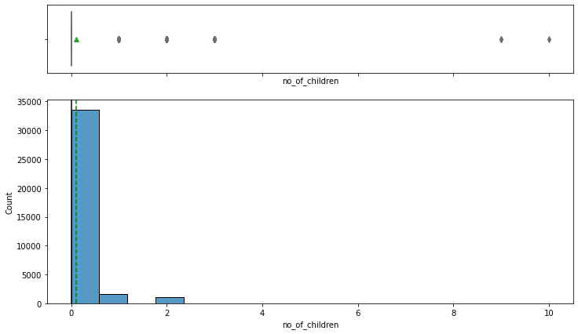

```python
histogram_boxplot(df1, "no_of_children")
```

#### Observation:

Very few bookings at the INN Hotels include children.

### C) no_of_weekend_nights

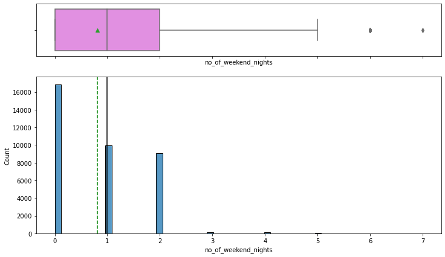

```python
histogram_boxplot(df, "no_of_weekend_nights")
```

### D) no_of_week_nights

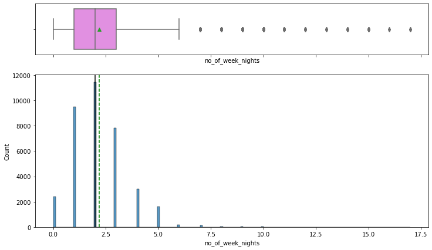

```python
histogram_boxplot(df1, "no_of_week_nights")
```

#### Observation:

The mean and mode for number of nights booked on weekdays is 2.

### E) type_of_meal_plan

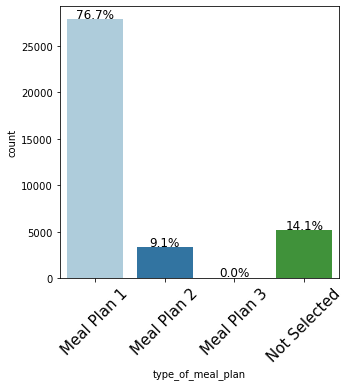

```python
labeled_barplot(df1, "type_of_meal_plan", perc=True)
```

#### Observation:

Most clients(76.7%) request Meal Plan 1 when booking.

### F) required_car_parking_space

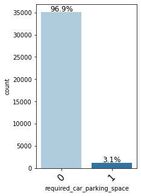

```python
labeled_barplot(df1, "required_car_parking_space", perc=True)
```

#### Observation:

Majority of clients do not require parking.

### G) room_type_reserved

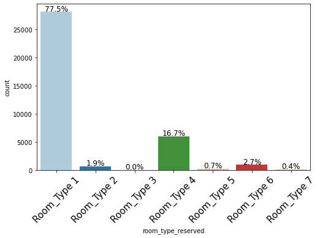

```python
labeled_barplot(df1, "room_type_reserved", perc=True)
```

#### Observation:

Room Type 1 is the most popular among clients

### H) lead_time

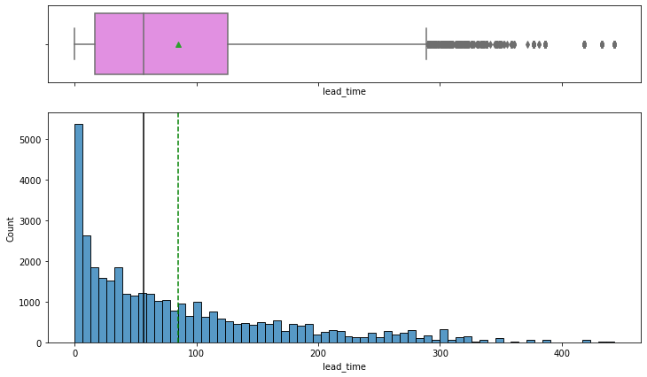

```python
histogram_boxplot(df1, "lead_time")
```

#### Observation:

Most clients book less than 100 days(mean=85 days) before visit.

### I) Arrival year

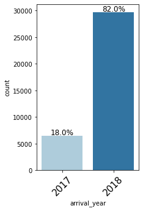

```python
df1["arrival_year"].value_counts(ascending=True)
labeled_barplot(df1, "arrival_year", perc=True)
```

#### Observation:

The hotel received more bookings in 2018 than 2017

### J) repeated_guest

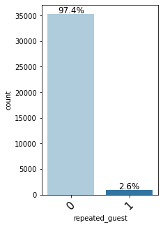

```python
labeled_barplot(df1, "repeated_guest", perc=True)
```

#### Observation:

Only 2.6% of clients are repeated guests

### K) no_of_previous_cancellations

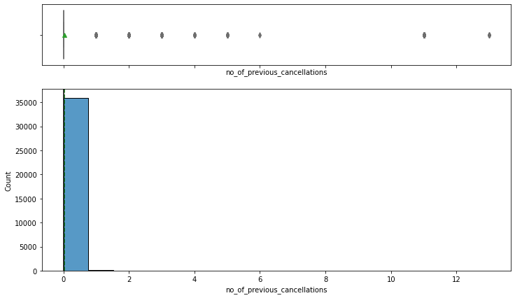

```python
histogram_boxplot(df1, "no_of_previous_cancellations")
```

#### Obsrevation:

Since majority of clients are first time guests, there are very few previous cancelations

### L) no_of_previous_bookings_not_canceled

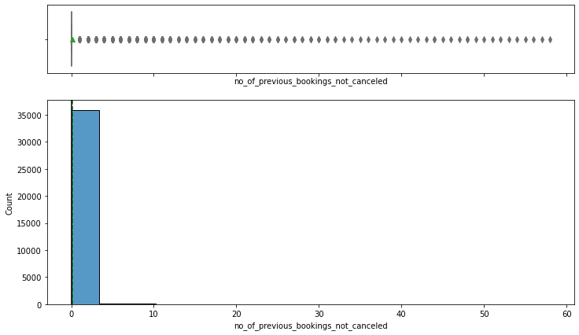

```python
histogram_boxplot(df1, "no_of_previous_bookings_not_canceled")
```

#### Observations:

Very few previous bookings have not been canceled.

### M) avg_price_per_room

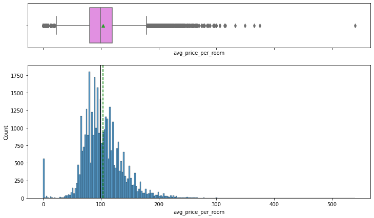

```python
histogram_boxplot(df1, "avg_price_per_room")
```

#### Observation

Average price of a room is 100 euros

### N) Booking Status

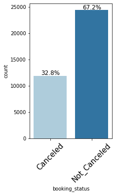

```python
labeled_barplot(df1, "booking_status", perc=True)
```

## Observation:

67.2% of clients do not cancel their bookings

## Bivariate Analysis

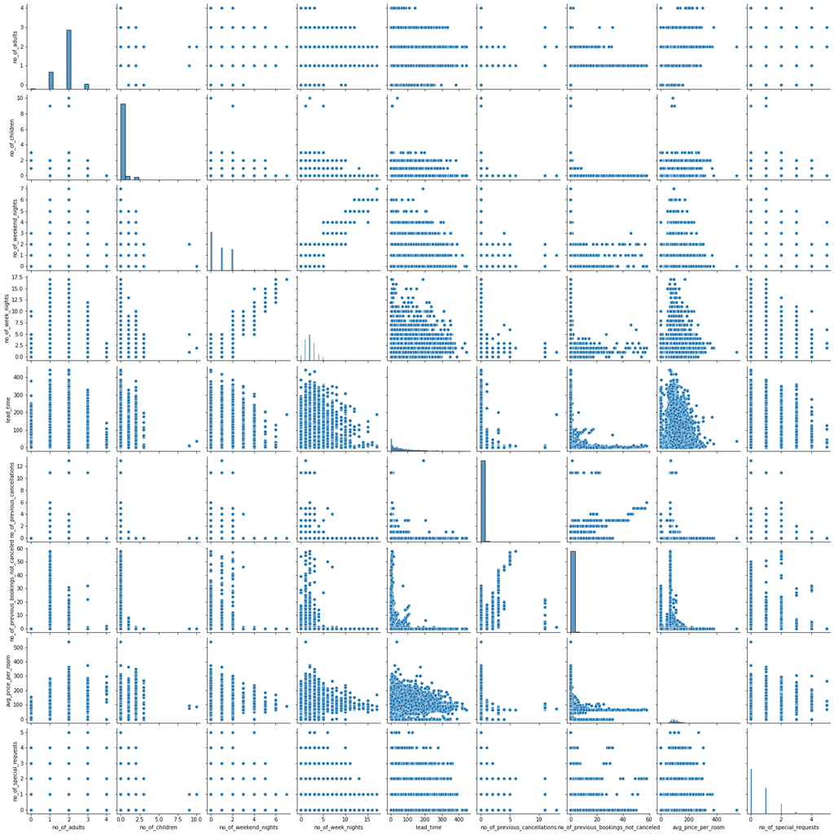

```python
sns.pairplot(df1)
plt.show()
```

```python
corr = df1.corr()
```

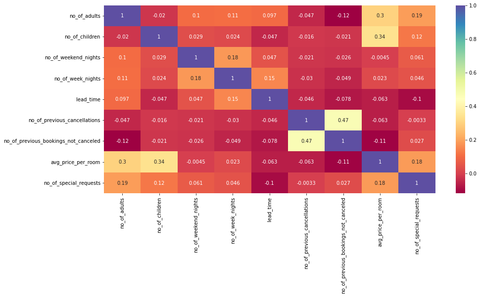

```python
plt.figure(figsize=(15, 7))
sns.heatmap(corr, annot=True, cmap="Spectral")
plt.show()
```

#### Observations:

1. The closest correlation is between the number of bookings canceled vs those not canceled (0.47).

## Data Preprocessing

- Missing value treatment (if needed)
- Feature engineering (if needed)
- Outlier detection and treatment (if needed)
- Preparing data for modeling
- Any other preprocessing steps (if needed)

### 1. Missing Value treatment

```python
df1["type_of_meal_plan"].value_counts()
```

```
Meal Plan 1     27835
Not Selected     5130
Meal Plan 2      3305
Meal Plan 3         5
Name: type_of_meal_plan, dtype: int64
```

```python
# Changing 'Not selected to NaN'
df1["type_of_meal_plan"] = df["type_of_meal_plan"].replace("Not Selected", np.nan)
```

```python
df1.isnull().sum().sort_values(
    ascending=False
)  # There are now null values in the dataset
```

```
type_of_meal_plan                       5130
Booking_ID                                 0
arrival_month                              0
no_of_special_requests                     0
avg_price_per_room                         0
no_of_previous_bookings_not_canceled       0
no_of_previous_cancellations               0
repeated_guest                             0
market_segment_type                        0
arrival_date                               0
arrival_year                               0
no_of_adults                               0
lead_time                                  0
room_type_reserved                         0
required_car_parking_space                 0
no_of_week_nights                          0
no_of_weekend_nights                       0
no_of_children                             0
booking_status                             0
dtype: int64
```

```python
# removing null values
df1.dropna(subset=["type_of_meal_plan"], inplace=True)
df1.isnull().sum().sort_values(ascending=False)
```

```
Booking_ID                              0
arrival_month                           0
no_of_special_requests                  0
avg_price_per_room                      0
no_of_previous_bookings_not_canceled    0
no_of_previous_cancellations            0
repeated_guest                          0
market_segment_type                     0
arrival_date                            0
arrival_year                            0
no_of_adults                            0
lead_time                               0
room_type_reserved                      0
required_car_parking_space              0
type_of_meal_plan                       0
no_of_week_nights                       0
no_of_weekend_nights                    0
no_of_children                          0
booking_status                          0
dtype: int64
```

### 2) Outlier Detection

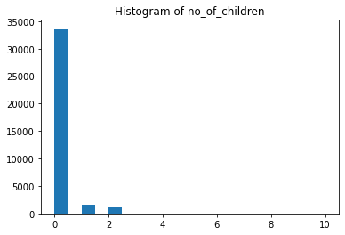

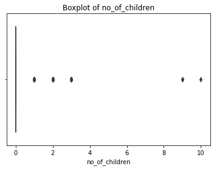

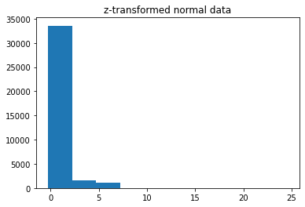

```python
plt.hist(df["no_of_children"], 20)
plt.title("Histogram of no_of_children")
plt.show()

sns.boxplot(df["no_of_children"])
plt.title("Boxplot of no_of_children")
plt.show()

# to detect true outliers
def z_transform(x):
    return (x - np.mean(x)) / np.std(x)


plt.hist(z_transform(df["no_of_children"]))
plt.title("z-transformed normal data")
plt.show()
```

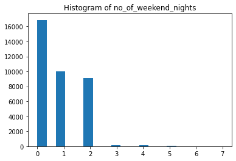

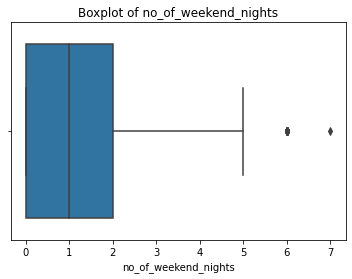

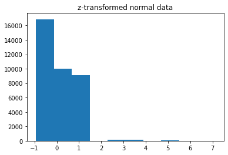

```python
plt.hist(df["no_of_weekend_nights"], 20)
plt.title("Histogram of no_of_weekend_nights")
plt.show()

sns.boxplot(df["no_of_weekend_nights"])
plt.title("Boxplot of no_of_weekend_nights")
plt.show()

# to detect true outliers
def z_transform(x):
    return (x - np.mean(x)) / np.std(x)


plt.hist(z_transform(df["no_of_weekend_nights"]))
plt.title("z-transformed normal data")
plt.show()
```

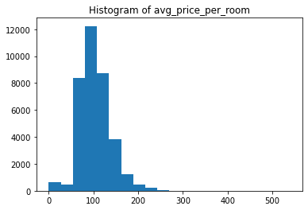

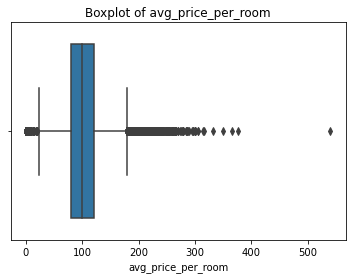

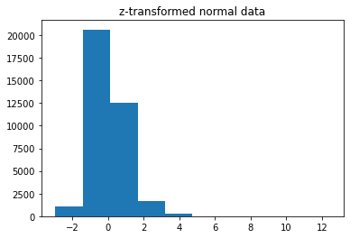

```python
plt.hist(df["avg_price_per_room"], 20)
plt.title("Histogram of avg_price_per_room")
plt.show()

sns.boxplot(df["avg_price_per_room"])
plt.title("Boxplot of avg_price_per_room")
plt.show()

# to detect true outliers
def z_transform(x):
    return (x - np.mean(x)) / np.std(x)


plt.hist(z_transform(df["avg_price_per_room"]))
plt.title("z-transformed normal data")
plt.show()
```

#### Comment:

Parameters noticed to have outliers during EDA were not treated because their values were considered to be significant. FRom the z- transformation of the above parameters which had seemingly extreme outliers, the outliers are still considered significant and thus will not be treated.

### 3. Data preparation

```python
# Drop columns
df1.drop(["Booking_ID", "arrival_date", "type_of_meal_plan"], axis=1, inplace=True)
```

```python
# Replace entries in 'booking_status' with zeros and ones
replaceStruct = {"booking_status": {"Not_Canceled": 0, "Canceled": 1}}
df1 = df1.replace(replaceStruct)
df1.head()
```

|  | no_of_adults | no_of_children | no_of_weekend_nights | no_of_week_nights | required_car_parking_space | room_type_reserved | lead_time | arrival_year | arrival_month | market_segment_type | repeated_guest | no_of_previous_cancellations | no_of_previous_bookings_not_canceled | avg_price_per_room | no_of_special_requests | booking_status |
| --- | --- | --- | --- | --- | --- | --- | --- | --- | --- | --- | --- | --- | --- | --- | --- | --- |
| 0 | 2 | 0 | 1 | 2 | 0 | Room_Type 1 | 224 | 2017 | 10 | Offline | 0 | 0 | 0 | 65.00 | 0 | 0 |
| 2 | 1 | 0 | 2 | 1 | 0 | Room_Type 1 | 1 | 2018 | 2 | Online | 0 | 0 | 0 | 60.00 | 0 | 1 |
| 3 | 2 | 0 | 0 | 2 | 0 | Room_Type 1 | 211 | 2018 | 5 | Online | 0 | 0 | 0 | 100.00 | 0 | 1 |
| 5 | 2 | 0 | 0 | 2 | 0 | Room_Type 1 | 346 | 2018 | 9 | Online | 0 | 0 | 0 | 115.00 | 1 | 1 |
| 6 | 2 | 0 | 1 | 3 | 0 | Room_Type 1 | 34 | 2017 | 10 | Online | 0 | 0 | 0 | 107.55 | 1 | 0 |

## EDA

- It is a good idea to explore the data once again after manipulating it.

```python
df1.shape
```

```
(31145, 16)
```

```python
df1.info()
```

```
<class 'pandas.core.frame.DataFrame'>
Int64Index: 31145 entries, 0 to 36274
Data columns (total 16 columns):
 #   Column                                Non-Null Count  Dtype
---  ------                                --------------  -----
 0   no_of_adults                          31145 non-null  int64
 1   no_of_children                        31145 non-null  int64
 2   no_of_weekend_nights                  31145 non-null  int64
 3   no_of_week_nights                     31145 non-null  int64
 4   required_car_parking_space            31145 non-null  category
 5   room_type_reserved                    31145 non-null  category
 6   lead_time                             31145 non-null  int64
 7   arrival_year                          31145 non-null  category
 8   arrival_month                         31145 non-null  category
 9   market_segment_type                   31145 non-null  category
 10  repeated_guest                        31145 non-null  category
 11  no_of_previous_cancellations          31145 non-null  int64
 12  no_of_previous_bookings_not_canceled  31145 non-null  int64
 13  avg_price_per_room                    31145 non-null  float64
 14  no_of_special_requests                31145 non-null  int64
 15  booking_status                        31145 non-null  int64
dtypes: category(6), float64(1), int64(9)
memory usage: 2.8 MB
```

```python
df1.isnull().sum().sort_values(ascending=False)
```

```
no_of_adults                            0
no_of_children                          0
no_of_weekend_nights                    0
no_of_week_nights                       0
required_car_parking_space              0
room_type_reserved                      0
lead_time                               0
arrival_year                            0
arrival_month                           0
market_segment_type                     0
repeated_guest                          0
no_of_previous_cancellations            0
no_of_previous_bookings_not_canceled    0
avg_price_per_room                      0
no_of_special_requests                  0
booking_status                          0
dtype: int64
```

```python
df1.describe().T
```

|  | count | mean | std | min | 25% | 50% | 75% | max |
| --- | --- | --- | --- | --- | --- | --- | --- | --- |
| no_of_adults | 31145.0 | 1.840616 | 0.541106 | 0.0 | 2.00 | 2.0 | 2.0 | 4.0 |
| no_of_children | 31145.0 | 0.118318 | 0.426644 | 0.0 | 0.00 | 0.0 | 0.0 | 10.0 |
| no_of_weekend_nights | 31145.0 | 0.815701 | 0.871240 | 0.0 | 0.00 | 1.0 | 2.0 | 7.0 |
| no_of_week_nights | 31145.0 | 2.245529 | 1.387713 | 0.0 | 1.00 | 2.0 | 3.0 | 17.0 |
| lead_time | 31145.0 | 89.537004 | 88.264526 | 0.0 | 19.00 | 62.0 | 134.0 | 443.0 |
| no_of_previous_cancellations | 31145.0 | 0.024306 | 0.356250 | 0.0 | 0.00 | 0.0 | 0.0 | 13.0 |
| no_of_previous_bookings_not_canceled | 31145.0 | 0.175405 | 1.881736 | 0.0 | 0.00 | 0.0 | 0.0 | 58.0 |
| avg_price_per_room | 31145.0 | 104.826062 | 36.338980 | 0.0 | 80.75 | 100.2 | 123.3 | 540.0 |
| no_of_special_requests | 31145.0 | 0.604431 | 0.789789 | 0.0 | 0.00 | 0.0 | 1.0 | 5.0 |
| booking_status | 31145.0 | 0.327051 | 0.469144 | 0.0 | 0.00 | 0.0 | 1.0 | 1.0 |

```python
df1.corr()
```

|  | no_of_adults | no_of_children | no_of_weekend_nights | no_of_week_nights | lead_time | no_of_previous_cancellations | no_of_previous_bookings_not_canceled | avg_price_per_room | no_of_special_requests | booking_status |
| --- | --- | --- | --- | --- | --- | --- | --- | --- | --- | --- |
| no_of_adults | 1.000000 | -0.018731 | 0.108984 | 0.111340 | 0.097598 | -0.054525 | -0.123340 | 0.323514 | 0.205519 | 0.086576 |
| no_of_children | -0.018731 | 1.000000 | 0.030505 | 0.020404 | -0.059945 | -0.018710 | -0.024131 | 0.346030 | 0.137091 | 0.041198 |
| no_of_weekend_nights | 0.108984 | 0.030505 | 1.000000 | 0.169393 | 0.032291 | -0.018154 | -0.027560 | 0.007355 | 0.072022 | 0.057525 |
| no_of_week_nights | 0.111340 | 0.020404 | 0.169393 | 1.000000 | 0.132056 | -0.034349 | -0.056025 | 0.034912 | 0.060319 | 0.086065 |
| lead_time | 0.097598 | -0.059945 | 0.032291 | 0.132056 | 1.000000 | -0.049346 | -0.085609 | -0.065303 | -0.103534 | 0.452249 |
| no_of_previous_cancellations | -0.054525 | -0.018710 | -0.018154 | -0.034349 | -0.049346 | 1.000000 | 0.491678 | -0.070571 | -0.001433 | -0.034884 |
| no_of_previous_bookings_not_canceled | -0.123340 | -0.024131 | -0.027560 | -0.056025 | -0.085609 | 0.491678 | 1.000000 | -0.121915 | 0.030874 | -0.064039 |
| avg_price_per_room | 0.323514 | 0.346030 | 0.007355 | 0.034912 | -0.065303 | -0.070571 | -0.121915 | 1.000000 | 0.198493 | 0.161850 |
| no_of_special_requests | 0.205519 | 0.137091 | 0.072022 | 0.060319 | -0.103534 | -0.001433 | 0.030874 | 0.198493 | 1.000000 | -0.236380 |
| booking_status | 0.086576 | 0.041198 | 0.057525 | 0.086065 | 0.452249 | -0.034884 | -0.064039 | 0.161850 | -0.236380 | 1.000000 |

## Building a Logistic Regression model

```python
# defining a function to compute different metrics to check performance of a classification model built using statsmodels
def model_performance_classification_statsmodels(
    model, predictors, target, threshold=0.5
):
    """
    Function to compute different metrics to check classification model performance

    model: classifier
    predictors: independent variables
    target: dependent variable
    threshold: threshold for classifying the observation as class 1
    """

    # checking which probabilities are greater than threshold
    pred_temp = model.predict(predictors) > threshold
    # rounding off the above values to get classes
    pred = np.round(pred_temp)

    acc = accuracy_score(target, pred)  # to compute Accuracy
    recall = recall_score(target, pred)  # to compute Recall
    precision = precision_score(target, pred)  # to compute Precision
    f1 = f1_score(target, pred)  # to compute F1-score

    # creating a dataframe of metrics
    df_perf = pd.DataFrame(
        {"Accuracy": acc, "Recall": recall, "Precision": precision, "F1": f1,},
        index=[0],
    )

    return df_perf
```

```python
# defining a function to plot the confusion_matrix of a classification model


def confusion_matrix_statsmodels(model, predictors, target, threshold=0.5):
    """
    To plot the confusion_matrix with percentages

    model: classifier
    predictors: independent variables
    target: dependent variable
    threshold: threshold for classifying the observation as class 1
    """
    y_pred = model.predict(predictors) > threshold
    cm = confusion_matrix(target, y_pred)
    labels = np.asarray(
        [
            ["{0:0.0f}".format(item) + "\n{0:.2%}".format(item / cm.flatten().sum())]
            for item in cm.flatten()
        ]
    ).reshape(2, 2)

    plt.figure(figsize=(6, 4))
    sns.heatmap(cm, annot=labels, fmt="")
    plt.ylabel("True label")
    plt.xlabel("Predicted label")
```

```python
X = df1.drop("booking_status", axis=1)
Y = df1["booking_status"]

# creating dummy variables
X = pd.get_dummies(X, drop_first=True)

# adding constant
X = sm.add_constant(X)

# splitting in training and test set
X_train, X_test, y_train, y_test = train_test_split(
    X, Y, test_size=0.3, random_state=1, stratify=Y
)
```

```python
df1.head()
```

|  | no_of_adults | no_of_children | no_of_weekend_nights | no_of_week_nights | required_car_parking_space | room_type_reserved | lead_time | arrival_year | arrival_month | market_segment_type | repeated_guest | no_of_previous_cancellations | no_of_previous_bookings_not_canceled | avg_price_per_room | no_of_special_requests | booking_status |
| --- | --- | --- | --- | --- | --- | --- | --- | --- | --- | --- | --- | --- | --- | --- | --- | --- |
| 0 | 2 | 0 | 1 | 2 | 0 | Room_Type 1 | 224 | 2017 | 10 | Offline | 0 | 0 | 0 | 65.00 | 0 | 0 |
| 2 | 1 | 0 | 2 | 1 | 0 | Room_Type 1 | 1 | 2018 | 2 | Online | 0 | 0 | 0 | 60.00 | 0 | 1 |
| 3 | 2 | 0 | 0 | 2 | 0 | Room_Type 1 | 211 | 2018 | 5 | Online | 0 | 0 | 0 | 100.00 | 0 | 1 |
| 5 | 2 | 0 | 0 | 2 | 0 | Room_Type 1 | 346 | 2018 | 9 | Online | 0 | 0 | 0 | 115.00 | 1 | 1 |
| 6 | 2 | 0 | 1 | 3 | 0 | Room_Type 1 | 34 | 2017 | 10 | Online | 0 | 0 | 0 | 107.55 | 1 | 0 |

```python
# fitting the model on training set
logit = sm.Logit(y_train, X_train.astype(float))
lg = logit.fit(
    disp=False
)  # setting disp=False will remove the information on number of iterations

print(lg.summary())
```

```
                           Logit Regression Results
==============================================================================
Dep. Variable:         booking_status   No. Observations:                21801
Model:                          Logit   Df Residuals:                    21767
Method:                           MLE   Df Model:                           33
Date:                Fri, 13 May 2022   Pseudo R-squ.:                  0.3577
Time:                        22:09:36   Log-Likelihood:                -8850.6
converged:                      False   LL-Null:                       -13780.
Covariance Type:            nonrobust   LLR p-value:                     0.000
========================================================================================================
                                           coef    std err          z      P>|z|      [0.025      0.975]
--------------------------------------------------------------------------------------------------------
const                                   -5.2072      0.369    -14.114      0.000      -5.930      -4.484
no_of_adults                             0.0952      0.041      2.339      0.019       0.015       0.175
no_of_children                           0.2199      0.062      3.550      0.000       0.099       0.341
no_of_weekend_nights                     0.1302      0.022      5.909      0.000       0.087       0.173
no_of_week_nights                        0.0323      0.014      2.340      0.019       0.005       0.059
lead_time                                0.0163      0.000     53.782      0.000       0.016       0.017
no_of_previous_cancellations             0.3081      0.120      2.560      0.010       0.072       0.544
no_of_previous_bookings_not_canceled    -0.0609      0.075     -0.808      0.419      -0.209       0.087
avg_price_per_room                       0.0199      0.001     23.327      0.000       0.018       0.022
no_of_special_requests                  -1.5057      0.033    -44.999      0.000      -1.571      -1.440
required_car_parking_space_1            -1.5667      0.151    -10.389      0.000      -1.862      -1.271
room_type_reserved_Room_Type 2          -0.3611      0.138     -2.613      0.009      -0.632      -0.090
room_type_reserved_Room_Type 3           0.5227      1.618      0.323      0.747      -2.648       3.693
room_type_reserved_Room_Type 4          -0.2512      0.054     -4.643      0.000      -0.357      -0.145
room_type_reserved_Room_Type 5          -0.6156      0.214     -2.873      0.004      -1.035      -0.196
room_type_reserved_Room_Type 6          -0.9742      0.155     -6.301      0.000      -1.277      -0.671
room_type_reserved_Room_Type 7          -1.5282      0.311     -4.920      0.000      -2.137      -0.919
arrival_year_2018                        0.3191      0.064      4.957      0.000       0.193       0.445
arrival_month_2                          2.5323      0.265      9.542      0.000       2.012       3.052
arrival_month_3                          2.2945      0.262      8.751      0.000       1.781       2.808
arrival_month_4                          1.9855      0.260      7.626      0.000       1.475       2.496
arrival_month_5                          1.7033      0.262      6.492      0.000       1.189       2.218
arrival_month_6                          1.8940      0.260      7.276      0.000       1.384       2.404
arrival_month_7                          1.7964      0.263      6.843      0.000       1.282       2.311
arrival_month_8                          1.7938      0.262      6.850      0.000       1.281       2.307
arrival_month_9                          1.6446      0.262      6.267      0.000       1.130       2.159
arrival_month_10                         1.9046      0.261      7.310      0.000       1.394       2.415
arrival_month_11                         2.2481      0.263      8.537      0.000       1.732       2.764
arrival_month_12                         0.1097      0.274      0.400      0.689      -0.427       0.646
market_segment_type_Complementary      -17.8090   1017.496     -0.018      0.986   -2012.066    1976.447
market_segment_type_Corporate           -1.1839      0.270     -4.379      0.000      -1.714      -0.654
market_segment_type_Offline             -1.9846      0.258     -7.698      0.000      -2.490      -1.479
market_segment_type_Online              -0.1716      0.254     -0.675      0.500      -0.670       0.327
repeated_guest_1                        -1.8488      0.503     -3.673      0.000      -2.835      -0.862
========================================================================================================
```